# set-3_abundance_6to8cell

Caroline Spike

2025-09-08

### Code to analyze set-3 abundance in embryos at the 6 to 8-cell stage

### Total abundance was quantified using Ce-bigFISH

### Code expects

set-3 smFISH data for wild-type, spn-4(tn1699), ccr-4(tm1312), ccf-1(tn2132), ccf-1(tn2168rf), CCF-1 depletion (CCF1aid), let-711(tn2130) and LET-711 depletion (LET711aid) embryos with 6to8 nuclei

CebigFISH settings used to generate these data:

Voxel size in nm: 250, 65, 65

set-3 spot size in nm: 300, 110, 110

chs-1 or lin-41 spot size in nm: 300, 97, 97

Embryos with >4000 set-3 spots had spot detection errors and were removed by the code.

```r
# Function to read and clean data from CSV files in subdirectories
read_data <- function(parent_directory) {

  # Function to read CSV and modify column names
  read_modify_csv <- function(file_path, subdirectory) {
    my_df <- read.csv(file_path, check.names = FALSE)  # Disable automatic name conversion
    # my_df$Image_ID <- file_path_sans_ext(basename(file_path))  # Removed to preserve actual Image ID
    my_df$subdirectory <- subdirectory

    # Remove unnecessary column if present (e.g., "X" from row indices)
    my_df <- my_df[, !colnames(my_df) %in% "X"]

    # Replace periods in column names with spaces
    colnames(my_df) <- gsub("\\.", " ", colnames(my_df))

    return(my_df)
  }

  # List all subdirectories (conditions) in the parent directory
  subdirectories <- list.dirs(parent_directory, full.names = FALSE, recursive = FALSE)

  # Initialize an empty list to store data frames
  all_data <- list()

  # Loop through subdirectories (conditions)
  for (subdirectory in subdirectories) {
    # List all CSV files in the current subdirectory
    csv_files <- list.files(path = file.path(parent_directory, subdirectory),
                            pattern = "\\.csv$", full.names = TRUE)  # Match .csv files only

    # Loop through CSV files, read data, and modify column names
    for (file_path in csv_files) {
      current_data <- read_modify_csv(file_path, subdirectory)
      all_data <- append(all_data, list(current_data))
    }
  }

  # Convert the Image_ID column to character and normalize column names
  all_data <- lapply(all_data, function(df) {
    colnames(df) <- str_replace_all(colnames(df), "[- ]", "_")  # Replace dashes and spaces with underscores
    df$Image_ID <- as.character(df$Image_ID)
    return(df)
  })

  # Combine all data frames
  combined_data <- bind_rows(all_data)

  # Filter out rows where 'set-3_mRNA_total_molecules' is 0 or > 4000, if this column exists
  if ("set_3_mRNA_total_molecules" %in% colnames(combined_data)) {
  combined_data <- combined_data %>%
    filter(set_3_mRNA_total_molecules != 0,
           set_3_mRNA_total_molecules <= 4000)
}

  # Make new informative columns
  combined_data <- combined_data %>%
    mutate(Nuclear_Stage = gsub("_.*", "", subdirectory),
           Strain = gsub("^(6to8_)", "", subdirectory))

  # Check the first few rows
  knitr::kable(head(combined_data))
  str(combined_data)

  # Save combined_data as a CSV file
  output_file <- file.path(parent_directory, "6to8cell_combined_quantification.csv")
  write.csv(combined_data, file = output_file, row.names = FALSE)
  message("Combined data saved at: ", output_file)

  return(combined_data)
}

# Usage example:
parent_directory <- "D:/Caroline/R_project_folders_set3/set3_6to8cell/data"
combined_data <- read_data(parent_directory)
```

```
## 'data.frame':    465 obs. of  7 variables:
##  $ Image_ID                   : chr  "70924_1008_crop.nd2" "70924_1011_crop.nd2" "70924_1015_crop.nd2" "70924_1083_crop.nd2" ...
##  $ set_3_mRNA_total_molecules : int  522 1089 1123 1000 1223 1079 844 948 1305 1428 ...
##  $ chs_1_mRNA_total_molecules : int  6133 7422 10770 6224 10663 5457 8059 6293 8946 11094 ...
##  $ subdirectory               : chr  "6to8_CCF1aid" "6to8_CCF1aid" "6to8_CCF1aid" "6to8_CCF1aid" ...
##  $ lin_41_mRNA_total_molecules: int  NA NA NA NA NA NA NA NA NA NA ...
##  $ Nuclear_Stage              : chr  "6to8" "6to8" "6to8" "6to8" ...
##  $ Strain                     : chr  "CCF1aid" "CCF1aid" "CCF1aid" "CCF1aid" ...
```

```
## Combined data saved at: D:/Caroline/R_project_folders_set3/set3_6to8cell/data/6to8cell_combined_quantification.csv
```

```r
# View combined data
knitr::kable(combined_data)
```

| Image_ID | set_3_mRNA_total_molecules | chs_1_mRNA_total_molecules | subdirectory | lin_41_mRNA_total_molecules | Nuclear_Stage | Strain |
| --- | --- | --- | --- | --- | --- | --- |
| 70924_1008_crop.nd2 | 522 | 6133 | 6to8_CCF1aid | NA | 6to8 | CCF1aid |
| 70924_1011_crop.nd2 | 1089 | 7422 | 6to8_CCF1aid | NA | 6to8 | CCF1aid |
| 70924_1015_crop.nd2 | 1123 | 10770 | 6to8_CCF1aid | NA | 6to8 | CCF1aid |
| 70924_1083_crop.nd2 | 1000 | 6224 | 6to8_CCF1aid | NA | 6to8 | CCF1aid |
| 70924_1106_crop.nd2 | 1223 | 10663 | 6to8_CCF1aid | NA | 6to8 | CCF1aid |
| 120524_11112_crop.nd2 | 1079 | 5457 | 6to8_CCF1aid | NA | 6to8 | CCF1aid |
| 120524_11145_crop_B.nd2 | 844 | 8059 | 6to8_CCF1aid | NA | 6to8 | CCF1aid |
| 70924_1119_crop.nd2 | 948 | 6293 | 6to8_CCF1aid | NA | 6to8 | CCF1aid |
| 70924_1124_crop.nd2 | 1305 | 8946 | 6to8_CCF1aid | NA | 6to8 | CCF1aid |
| 70924_1196_crop.nd2 | 1428 | 11094 | 6to8_CCF1aid | NA | 6to8 | CCF1aid |
| 70924_1203_crop.nd2 | 1264 | 11199 | 6to8_CCF1aid | NA | 6to8 | CCF1aid |
| 70924_1213_crop.nd2 | 975 | 5332 | 6to8_CCF1aid | NA | 6to8 | CCF1aid |
| 70924_1263_crop.nd2 | 1097 | 5947 | 6to8_CCF1aid | NA | 6to8 | CCF1aid |
| 70924_12630_cropB.nd2 | 1146 | 8109 | 6to8_CCF1aid | NA | 6to8 | CCF1aid |
| 70924_1280_crop.nd2 | 1059 | 6051 | 6to8_CCF1aid | NA | 6to8 | CCF1aid |
| 70924_1329_crop.nd2 | 1138 | 8561 | 6to8_CCF1aid | NA | 6to8 | CCF1aid |
| 70924_1439_crop.nd2 | 1322 | 12075 | 6to8_CCF1aid | NA | 6to8 | CCF1aid |
| 250610_1198_crop.nd2 | 945 | NA | 6to8_CCF1aid | 7605 | 6to8 | CCF1aid |
| 250610_1203_crop.nd2 | 1005 | NA | 6to8_CCF1aid | 9809 | 6to8 | CCF1aid |
| 091724_1242_crop.nd2 | 1179 | NA | 6to8_CCF1aid | 10825 | 6to8 | CCF1aid |
| 091724_1248_crop.nd2 | 996 | NA | 6to8_CCF1aid | 7779 | 6to8 | CCF1aid |
| 091724_1253_crop.nd2 | 1248 | NA | 6to8_CCF1aid | 10436 | 6to8 | CCF1aid |
| 250610_1253_crop.nd2 | 587 | NA | 6to8_CCF1aid | 9404 | 6to8 | CCF1aid |
| 091724_1273_crop.nd2 | 950 | NA | 6to8_CCF1aid | 9048 | 6to8 | CCF1aid |
| 091724_1277_crop.nd2 | 952 | NA | 6to8_CCF1aid | 7843 | 6to8 | CCF1aid |
| 250611_1307_crop.nd2 | 622 | NA | 6to8_CCF1aid | 9372 | 6to8 | CCF1aid |
| 091724_1309_crop.nd2 | 1016 | NA | 6to8_CCF1aid | 11683 | 6to8 | CCF1aid |
| 250611_1310_crop.nd2 | 678 | NA | 6to8_CCF1aid | 6648 | 6to8 | CCF1aid |
| 250611_1357_crop.nd2 | 1110 | NA | 6to8_CCF1aid | 12091 | 6to8 | CCF1aid |
| 091724_1358_crop.nd2 | 1305 | NA | 6to8_CCF1aid | 11739 | 6to8 | CCF1aid |

[output cut: 435 more lines]

```r
str(combined_data)
```

```
## 'data.frame':    465 obs. of  7 variables:
##  $ Image_ID                   : chr  "70924_1008_crop.nd2" "70924_1011_crop.nd2" "70924_1015_crop.nd2" "70924_1083_crop.nd2" ...
##  $ set_3_mRNA_total_molecules : int  522 1089 1123 1000 1223 1079 844 948 1305 1428 ...
##  $ chs_1_mRNA_total_molecules : int  6133 7422 10770 6224 10663 5457 8059 6293 8946 11094 ...
##  $ subdirectory               : chr  "6to8_CCF1aid" "6to8_CCF1aid" "6to8_CCF1aid" "6to8_CCF1aid" ...
##  $ lin_41_mRNA_total_molecules: int  NA NA NA NA NA NA NA NA NA NA ...
##  $ Nuclear_Stage              : chr  "6to8" "6to8" "6to8" "6to8" ...
##  $ Strain                     : chr  "CCF1aid" "CCF1aid" "CCF1aid" "CCF1aid" ...
```

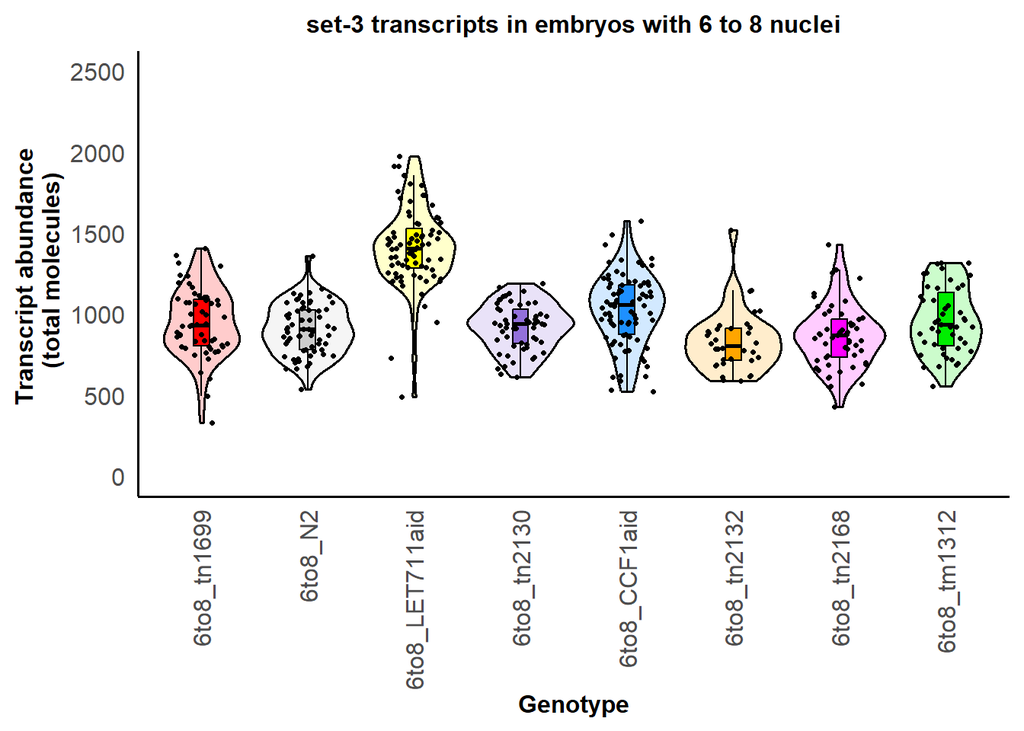

```r
# Define the custom order for subdirectories
custom_order <- c("6to8_tn1699", "6to8_N2", "6to8_LET711aid", "6to8_tn2130", "6to8_CCF1aid", "6to8_tn2132", "6to8_tn2168", "6to8_tm1312")

# Convert subdirectory to a factor with custom order
combined_data$subdirectory <- factor(combined_data$subdirectory, levels = custom_order)

# Define custom fill colors for the subdirectories
fill_colors <- c(
  "6to8_N2" = "gray80",
  "6to8_tn2132" = "orange",
  "6to8_CCF1aid" = "dodgerblue",
  "6to8_tn1699" = "red",
  "6to8_tm1312" = "green2",
  "6to8_tn2168" = "magenta",
  "6to8_tn2130" = "mediumpurple",
  "6to8_LET711aid" = "yellow"
)

# Create a combined violin and boxplot (flipped vertically)
p <- ggplot(combined_data, aes(x = factor(subdirectory, levels = custom_order), y = `set_3_mRNA_total_molecules`, fill = subdirectory)) +
  geom_violin(alpha = 0.2, color = "black", size = 0.6, width = 1.0, position = position_dodge(width = 0.8)) +
  geom_boxplot(width = 0.15, outlier.shape = NA, color = "black", notch = "false") +
  geom_jitter(height = 0, width = 0.25, color = "black", size = 0.9) +
  labs(title = "set-3 transcripts in embryos with 6 to 8 nuclei",
       x = "Genotype",
       y = "Transcript abundance \n (total molecules)") +
  scale_fill_manual(values = fill_colors) +
  theme_minimal(base_size = 14) +
  theme(axis.text.x = element_text(angle = 90, vjust = 0.5, hjust=1),  # Rotate labels on x-axis
        legend.position = "none",  # Remove legend
        panel.grid.major = element_blank(),
        panel.grid.minor = element_blank(),
        panel.border = element_blank(),
        axis.line = element_line(color = "black"),
        plot.title = element_text(hjust = 0.5, size = 12, face = "bold"),
        axis.title = element_text(size = 12, face = "bold"),
        axis.text = element_text(size = 12),
        axis.ticks = element_blank()) +
  coord_cartesian(ylim = c(0, 2500))

# Display the plot
print(p)
```

```r
# Save the plot as SVG with the date in the filename
ggsave(paste0("D:/Caroline/R_project_folders_set3/set3_6to8cell/output/",
              date_today, "_set-3-mRNA-abundance-violin-plot.svg"),
       p, width = 10, height = 8)

# Save the plot as PDF with the date in the filename
ggsave(paste0("D:/Caroline/R_project_folders_set3/set3_6to8cell/output/",
              date_today, "_set-3-mRNA-abundance-violin-plot.pdf"),
       p, width = 10, height = 8)
```

Statistical analysis

Shapiro-Wilk: Test for normal distribution.

Levene: Test for equal variance.

Welch’s test: Parametric test for differences among groups. Does not assume equal variance.

Games-Howell test: A post-hoc test for Welch’s ttest.

Kruskal-Wallis: Non-parametric test for differences among groups.

Dunn test: A post-hoc test for Kruskal-Wallis. Used Benjamini-Hochberg correction for multiple testing.

Conover-Iman test: A more sensitive post-hoc test for Kruskal-Wallis. A more conservative Benjamini-Yekutieli correction for multiple testing.

```r
# Test significant differences in set-3 mRNA abundance between each "subdirectory" ( dev. stage + strain)
# Shapiro-Wilk test for normal distributions
shapiro_result <- shapiro.test(combined_data$set_3_mRNA_total_molecules)
by(combined_data$set_3_mRNA_total_molecules, combined_data$subdirectory, shapiro.test)
```

```
## combined_data$subdirectory: 6to8_tn1699
##
##  Shapiro-Wilk normality test
##
## data:  dd[x, ]
## W = 0.98007, p-value = 0.4908
##
## --------------------------------------------------------------------------------------------------------------------------
## combined_data$subdirectory: 6to8_N2
##
##  Shapiro-Wilk normality test
##
## data:  dd[x, ]
## W = 0.98447, p-value = 0.5898
##
## --------------------------------------------------------------------------------------------------------------------------
## combined_data$subdirectory: 6to8_LET711aid
##
##  Shapiro-Wilk normality test
##
## data:  dd[x, ]
## W = 0.94814, p-value = 0.003656
##
## --------------------------------------------------------------------------------------------------------------------------
## combined_data$subdirectory: 6to8_tn2130
##
##  Shapiro-Wilk normality test
##
## data:  dd[x, ]
## W = 0.97878, p-value = 0.4376
##
## --------------------------------------------------------------------------------------------------------------------------
## combined_data$subdirectory: 6to8_CCF1aid
##
##  Shapiro-Wilk normality test
##
## data:  dd[x, ]
## W = 0.98603, p-value = 0.5367
##
## --------------------------------------------------------------------------------------------------------------------------
## combined_data$subdirectory: 6to8_tn2132
##
##  Shapiro-Wilk normality test
##
## data:  dd[x, ]
## W = 0.88728, p-value = 0.002152
##
## --------------------------------------------------------------------------------------------------------------------------
## combined_data$subdirectory: 6to8_tn2168
##
##  Shapiro-Wilk normality test
##
## data:  dd[x, ]
## W = 0.98081, p-value = 0.548
##
## --------------------------------------------------------------------------------------------------------------------------
## combined_data$subdirectory: 6to8_tm1312
##
##  Shapiro-Wilk normality test
##
## data:  dd[x, ]
## W = 0.96337, p-value = 0.1463
```

```r
# Test homogeneity of variance using Levene's Test.
leveneTest(set_3_mRNA_total_molecules ~ subdirectory, data = combined_data)
```

```
## Levene's Test for Homogeneity of Variance (center = median)
##        Df F value  Pr(>F)
## group   7  2.1319 0.03914 *
##       457
## ---
## Signif. codes:  0 '***' 0.001 '**' 0.01 '*' 0.05 '.' 0.1 ' ' 1
```

```r
# Welch's ANOVA: a parametric test that does not assume equal variance
oneway.test(set_3_mRNA_total_molecules ~ subdirectory, data = combined_data)
```

```
##
##  One-way analysis of means (not assuming equal variances)
##
## data:  set_3_mRNA_total_molecules and subdirectory
## F = 42.463, num df = 7.00, denom df = 180.08, p-value < 2.2e-16
```

```r
# Games Howell: a post-hoc test for Welch's ANOVA
# Games-Howell test
games_results <- combined_data %>%
  games_howell_test(set_3_mRNA_total_molecules ~ subdirectory)

# Display Games-Howell post hoc test results
games_results_df <- as.data.frame(games_results)
games_results_df %>%
  dplyr::select(group1, group2, estimate, p.adj, p.adj.signif) %>%
  print()
```

```
##            group1         group2   estimate    p.adj p.adj.signif
## 1     6to8_tn1699        6to8_N2  -43.83916 9.08e-01           ns
## 2     6to8_tn1699 6to8_LET711aid  464.36388 0.00e+00         ****
## 3     6to8_tn1699    6to8_tn2130  -29.90909 9.89e-01           ns
## 4     6to8_tn1699   6to8_CCF1aid   76.24545 4.80e-01           ns
## 5     6to8_tn1699    6to8_tn2132 -116.78396 1.37e-01           ns
## 6     6to8_tn1699    6to8_tn2168  -84.66964 3.85e-01           ns
## 7     6to8_tn1699    6to8_tm1312   12.25609 1.00e+00           ns
## 8         6to8_N2 6to8_LET711aid  508.20304 0.00e+00         ****
## 9         6to8_N2    6to8_tn2130   13.93007 1.00e+00           ns
## 10        6to8_N2   6to8_CCF1aid  120.08462 5.00e-03           **
## 11        6to8_N2    6to8_tn2132  -72.94480 5.28e-01           ns
## 12        6to8_N2    6to8_tn2168  -40.83048 9.17e-01           ns
## 13        6to8_N2    6to8_tm1312   56.09525 7.55e-01           ns
## 14 6to8_LET711aid    6to8_tn2130 -494.27297 7.72e-14         ****
## 15 6to8_LET711aid   6to8_CCF1aid -388.11842 4.54e-14         ****
## 16 6to8_LET711aid    6to8_tn2132 -581.14783 5.94e-11         ****
## 17 6to8_LET711aid    6to8_tn2168 -549.03352 9.21e-15         ****
## 18 6to8_LET711aid    6to8_tm1312 -452.10778 4.66e-14         ****
## 19    6to8_tn2130   6to8_CCF1aid  106.15455 2.20e-02            *
## 20    6to8_tn2130    6to8_tn2132  -86.87487 3.09e-01           ns
## 21    6to8_tn2130    6to8_tn2168  -54.76055 7.16e-01           ns
## 22    6to8_tn2130    6to8_tm1312   42.16518 9.33e-01           ns
## 23   6to8_CCF1aid    6to8_tn2132 -193.02941 2.63e-04          ***
## 24   6to8_CCF1aid    6to8_tn2168 -160.91509 5.77e-04          ***
## 25   6to8_CCF1aid    6to8_tm1312  -63.98936 7.15e-01           ns
## 26    6to8_tn2132    6to8_tn2168   32.11432 9.94e-01           ns
## 27    6to8_tn2132    6to8_tm1312  129.04005 7.80e-02           ns
## 28    6to8_tn2168    6to8_tm1312   96.92573 2.40e-01           ns
```

```r
# Kruskal-Wallis non-parametric test may be more appropriate. The distributions of two subgroups deviate significantly from normality.
kruskal.test(set_3_mRNA_total_molecules ~ subdirectory, data = combined_data)
```

```
##
##  Kruskal-Wallis rank sum test
##
## data:  set_3_mRNA_total_molecules by subdirectory
## Kruskal-Wallis chi-squared = 176.2, df = 7, p-value < 2.2e-16
```

```r
# Use the Dunn test to determine significance between groups.
dunn_results <- combined_data %>%
  dunn_test(set_3_mRNA_total_molecules ~ subdirectory, p.adjust.method = "BH")

# Summarize the results of the Dunn test.
dunn_results %>%
  dplyr::mutate(
    p.adj = signif(p.adj, 3)
  ) %>%
  dplyr::select(group1, group2, p.adj, p.adj.signif) %>%
  dplyr::arrange(p.adj) %>%
  print(n = Inf)
```

```
## # A tibble: 28 × 4
##    group1         group2            p.adj p.adj.signif
##    <chr>          <chr>             <dbl> <chr>
##  1 6to8_LET711aid 6to8_tn2168    4.26e-23 ****
##  2 6to8_N2        6to8_LET711aid 1.83e-21 ****
##  3 6to8_LET711aid 6to8_tn2132    1.83e-21 ****
##  4 6to8_LET711aid 6to8_tn2130    8.08e-18 ****
##  5 6to8_tn1699    6to8_LET711aid 2.47e-15 ****
##  6 6to8_LET711aid 6to8_tm1312    1.29e-13 ****
##  7 6to8_LET711aid 6to8_CCF1aid   1.53e-11 ****
##  8 6to8_CCF1aid   6to8_tn2132    4.02e- 5 ****
##  9 6to8_CCF1aid   6to8_tn2168    1.58e- 4 ***
## 10 6to8_N2        6to8_CCF1aid   3.88e- 3 **
## 11 6to8_tn2132    6to8_tm1312    2   e- 2 *
## 12 6to8_tn1699    6to8_tn2132    2.05e- 2 *
```

[output cut: 16 more lines]

```r
# Save Dunn's output as a csv
dunn_summary <- dunn_results %>%
  dplyr::mutate(
    p.adj = signif(p.adj, 3)
  ) %>%
  dplyr::select(group1, group2, p.adj, p.adj.signif) %>%
  dplyr::arrange(p.adj)

write.csv(dunn_summary,
          file = paste0("D:/Caroline/R_project_folders_set3/set3_6to8cell/output/", date_today, "_dunn_results.csv"),
          row.names = FALSE)

# Run Conover-Iman test with Benjamini-Yekutieli correction to determine significance between groups.
conover_result <- kwAllPairsConoverTest(set_3_mRNA_total_molecules ~ subdirectory,
                                data = combined_data,
                                p.adjust.method = "BY")

# Display Conover-Iman post hoc test results
print(conover_result)
```

```
##
##  Pairwise comparisons using Conover's all-pairs test
```

```
## data: set_3_mRNA_total_molecules by subdirectory
```

```
##                6to8_tn1699 6to8_N2 6to8_LET711aid 6to8_tn2130 6to8_CCF1aid 6to8_tn2132 6to8_tn2168
## 6to8_N2        0.77076     -       -              -           -            -           -
## 6to8_LET711aid < 2e-16     < 2e-16 -              -           -            -           -
## 6to8_tn2130    1.00000     1.00000 < 2e-16        -           -            -           -
## 6to8_CCF1aid   0.12458     0.00072 6.5e-16        0.01122     -            -           -
## 6to8_tn2132    0.00950     0.18746 < 2e-16        0.07176     7.5e-07      -           -
## 6to8_tn2168    0.07383     1.00000 < 2e-16        0.43533     5.9e-06      1.00000     -
## 6to8_tm1312    1.00000     0.64899 < 2e-16        1.00000     0.23375      0.00879     0.06961
```

```
##
## P value adjustment method: BY
```

```r
# Extract and convert Conover-Iman results to a data frame
conover_summary <- as.data.frame(conover_result$p.value)

# Save to CSV
write.csv(conover_summary,
          file = paste0("D:/Caroline/R_project_folders_set3/set3_6to8cell/output/",
                        date_today, "_conover_results.csv"),
          row.names = TRUE)

# Summarize important metrics that describe the underlying data.
combined_data %>%
  group_by(subdirectory) %>%
  summarize(mean = mean(set_3_mRNA_total_molecules),
            median = median(set_3_mRNA_total_molecules),
            sd = sd(set_3_mRNA_total_molecules),
            n = n())
```

```
## # A tibble: 8 × 5
##   subdirectory    mean median    sd     n
##   <fct>          <dbl>  <dbl> <dbl> <int>
## 1 6to8_tn1699     951.   930   213.    55
## 2 6to8_N2         907.   906   154.    65
## 3 6to8_LET711aid 1416.  1408   246.    76
## 4 6to8_tn2130     921.   939   145.    55
## 5 6to8_CCF1aid   1028.  1056.  222.    80
## 6 6to8_tn2132     834.   804   188.    34
## 7 6to8_tn2168     867.   873   195.    53
## 8 6to8_tm1312     964.   938   203.    47
```